# Predicting Horror Movie Preferences Through Machine Learning Models

Dannah Golich

2023-10-13

# **Introduction**

Have you ever wondered if your personality influences the types of movies that you like? I have too! Research has indicated that there is a relationship between personality and media preferences (Manolika 1). In an attempt to predict a person’s interest in horror movies, we will be using the dataset from *The Big Five and Beyond: Which Personality Traits Do Predict Movie and Reading Preferences?* found in the Harvard Dataverse. It includes the participants’ rating of various genres of movies and books, responses to 32 total personality typing questions, and demographics. Since this project will only focus on horror movie ratings, we will remove the ratings for other genres before we fit the dataset to our models.

Before diving deeper into the variables, let’s load in our dataset and prepare it for our analysis. First, load in the necessary packages to run the code into the library.

```r
library(tidyverse)
library(tidymodels)
library(ISLR)
library(kknn)
library(yardstick)
library(ggplot2)
library(corrplot)
library(corrr)
library(discrim)
library(themis)
library(naniar)
library(kableExtra)
library(haven)
library(janitor)
library(plotly)
library(keras)
library(tensorflow)
```

Now, it’s time to load in the dataset.

```r
# read in sav file
original_dataset <- read_sav("data/bigfiveandbeyond.sav")
```

Since our goal is to predict a person’s preference in horror movies based on their answers to personality type questions and demographics, the columns of other movie and book genres will need to be removed from this dataset.

```r
# removing columns of other genres of movies and books
genre_dataset <- subset(original_dataset, select=-c(1:3,5:48))
```

To tidy the data, the variable `Horror_04` is renamed to `horror`, since we are not considering other genres. Then, all the column names will be tidied to improve the consistency of the variables.

```r
# renaming horror
colnames(genre_dataset)[1] ="horror"
# clean variable names
genre_dataset <- clean_names(genre_dataset)
```

## *Variables Description*

The majority of the variables we are using for our analysis are ordinal variables, meaning the variables are categorical and ranked numerically, with the exception of `gender` and `age`. Variables that begin with `ipip` represent responses to the Mini-International Personality Item Pool. Variables that begin with `dd` represent responses to the Dirty Dozen. Participants were asked to rank their agreement with the statements, with responses for both of these pools of questions on a scale from 1 (strongly disagree) to 5 (strongly agree).

The Mini-IPIP is a shortened version of the Big Five Personality Test, which assesses a person’s extraversion, agreeableness, conscientiousness, neuroticism, and intellect/imagination. Below indicates which statements are associated with one of the five personality traits:

| Statements | Trait |
| --- | --- |
| 1,6,11,16 | extraversion |
| 2,7,12,17 | agreeableness |
| 3,8,13,18 | conscientiousness |
| 4,9,14,19 | neuroticism |
| 5,10,15,20 | intellect/imagination |

Please note that `ipip_01` corresponds to statement 1 as indicated in this chart. Additionally, some variables’ naming convention, such as `ipip_06r`, include r at the end of the variable name. This indicates that these variables are meant to be reverse scored. For example, a response of 5 to `ipip_06` is scored as 1 point for extraversion.

The Dirty Dozen is a shortened version of the 91-item Dark Triad Personality Test, which assesses machiavellianism, psychopathy, and narcissism. The following table associates the statements with certain Dark Triad traits:

| Statements | Trait |
| --- | --- |
| 1,2,3,4 | machiavellianism |
| 5,6,7,8 | psychopathy |
| 9,10,11,12 | narcissism |

Please note that `dd_01` corresponds to statement 1 as indicated in this chart.

Refer to the codebook for complete descriptions of the variables.

# **Exploratory Data Analysis**

## *Preparing the Data for Analysis*

We established that all of the responses to the personality test statements are ordinal variables. Thus, we will not factor these ordinal variables; there is useful information within the difference between a rating of 1 and 2, for example, that would be removed with by the factor. `gender` needs to be factored, since it is categorical variable. Additionally, we will need to factor the rating for horror movies, since this step is necessary for the models to predict it as a categorical variable, even though this variable is technically an ordinal variable.

```r
# set gender as a factor
genre_dataset$gender <- as.factor(genre_dataset$gender)
# set horror as a factor
genre_dataset$horror <- as.factor(genre_dataset$horror)
```

It’s time to explore the dataset!

## *Missing Data*

The study mentions that there are some missing observations of `age` and `gender`, so let’s visualize the data before splitting into testing and training datasets. This will allow us to can handle the missing data appropriately.

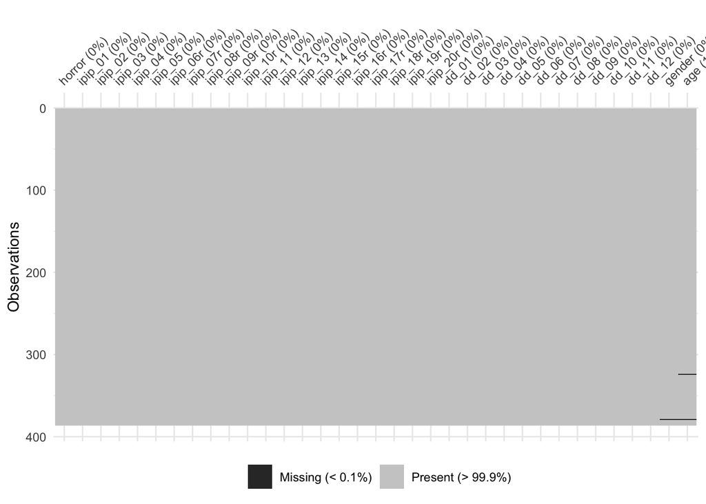

```r
vis_miss(genre_dataset)
```

As we can see, there is only missing data for `gender` and `age` for two observations.

```r
which(is.na(genre_dataset$age))
```

```
## [1] 324 379
```

```r
which(is.na(genre_dataset$gender))
```

```
## [1] 379
```

Observations 324 and 379 have these missing values.

```r
# number of observations
nrow(genre_dataset)
```

```
## [1] 386
```

Since the dataset has nearly 400 observations, we will simply remove these observations and proceed with the remainder of the dataset.

```r
# removing incomplete observations
removed_rows <- genre_dataset[c(324,379),]
genre_dataset <- genre_dataset[-c(324,379),]
```

## *Training and Testing Datasets*

Next, let’s create our training and testing datasets. First, we will use `set.seed()` for reproducible results, as the function ensures we will get the same randomization each time we set the seed at a certain number. The training dataset will be used to fit to our model, thus “training” our model. The testing dataset will then be given to the model, acting as data the model has never seen before, to assess its performance to accurately predict `horror`. We will use a proportion of 0.75 of our original dataset for our training dataset and 0.25 for our testing dataset. I believe these proportions will ensure there is both enough data for the model to train on and enough data for the trained model to predict. When using `initial_split()` to create the training and testing dataset, we will also use stratified sampling. This ensures that the proportion of each rating for `horror` is the same as in our entire dataset. Thus, the model will be trained on each possible `horror` outcome, so it can most accurately predict each outcome when it’s fit to the testing dataset.

```r
# ensure reproducible results
set.seed(676)
# splitting data with strata
genre_split <- initial_split(genre_dataset, prop = 0.75, strata = horror)
genre_train <- training(genre_split)
genre_test <- testing(genre_split)
```

## *`horror` Analysis*

Now, let’s investigate our response variable, `horror` within our training dataset. We want to use the training dataset because the remaining data in testing dataset should be treated as completely new data that we have never seen before.

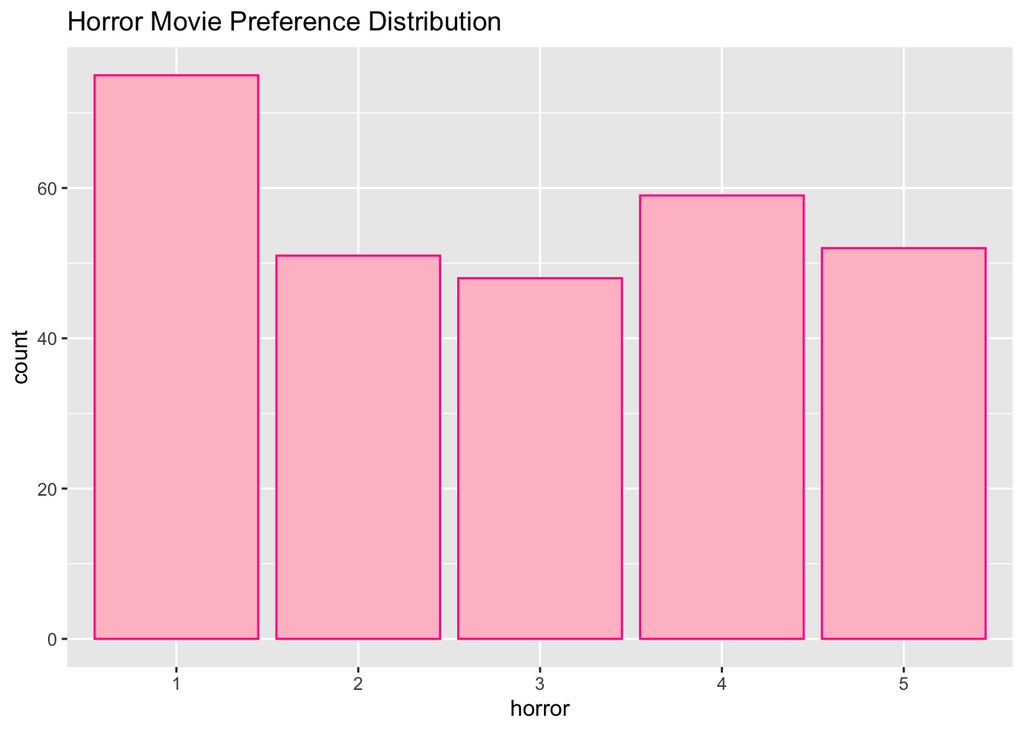

```r
# bar plotof horror to assess the distribution
genre_train %>%
  ggplot(aes(x= horror)) +
  geom_bar(color="deeppink", fill="pink") +
  labs(title="Horror Movie Preference Distribution")
```

As shown by this bar plot, the distribution of `horror` is relatively uniform among each possible response value, except for the rating of 1, which has the most observations. Since we used stratified sampling, we can assume that the complete dataset has similar proportions of the `horror` outcome as shown in this bar plot. Additionally, because there is a relatively even amount of each response, our model is able to train on each possible value of `horror`.

In order to visualize how different variables influence each other, let’s create a correlation plot of the Dirty Dozen variables and numeric predictors. As such, `gender` and `horror` will be excluded.

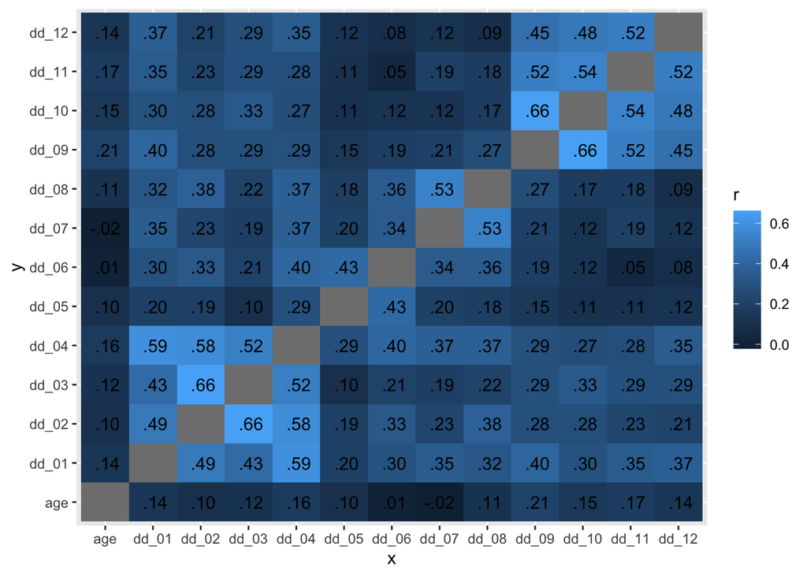

```r
genre_cor <- genre_train %>%
  select(-starts_with("ipip")) %>%
  correlate()
genre_cor %>%
  stretch() %>%
  ggplot(aes(x, y, fill = r)) +
  geom_tile() +
  geom_text(aes(label = as.character(fashion(r))))
```

As we can see, `age` does not have a strong correlation with any of the Dirty Dozen questions. The strongest correlation is 0.66 between `dd_02` and `dd_03`, and `dd_09` and `dd_10`. This is to be expected, as the Dirty Dozen questions 2 and 3 both assess machiavellianism, and Dirty Dozen questions 9 and 10 both assess narcissism. There appears to be lighter blue areas on this correlation plot where different statements assess the same personality trait, which means that the study’s method of assessing personality appears credible.

Let’s investigate the relationships between the IPIP variables and `age`. Like before, `gender` and `horror` will be excluded.

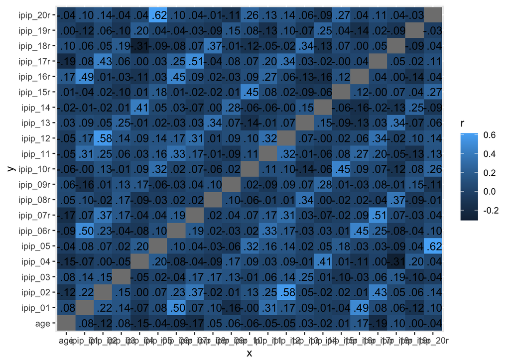

```r
genre_cor <- genre_train %>%
  select(-starts_with("dd")) %>%
  correlate()
genre_cor %>%
  stretch() %>%
  ggplot(aes(x, y, fill = r)) +
  geom_tile() +
  geom_text(aes(label = as.character(fashion(r))))
```

As in the other correlation plot, `age` does not seem to be strongly correlated with the IPIP personality test responses. The highest correlation is 0.62 between `ipip_05` and `ipip_20r`. This is as expected, since both these questions assess intellect/imagination. Additionally, there is a clear diagonal pattern every 4 correlation squares that mirrors the blank correlation line. This makes sense, as these lines represent correlations between different questions that assess the same trait. This solidifies, with the previous plot, that the methods for assessing personality are consistent assessing personality type.

For some further analysis about our response variable `horror`, let’s look at the `gender` distribution within each level of `horror`.

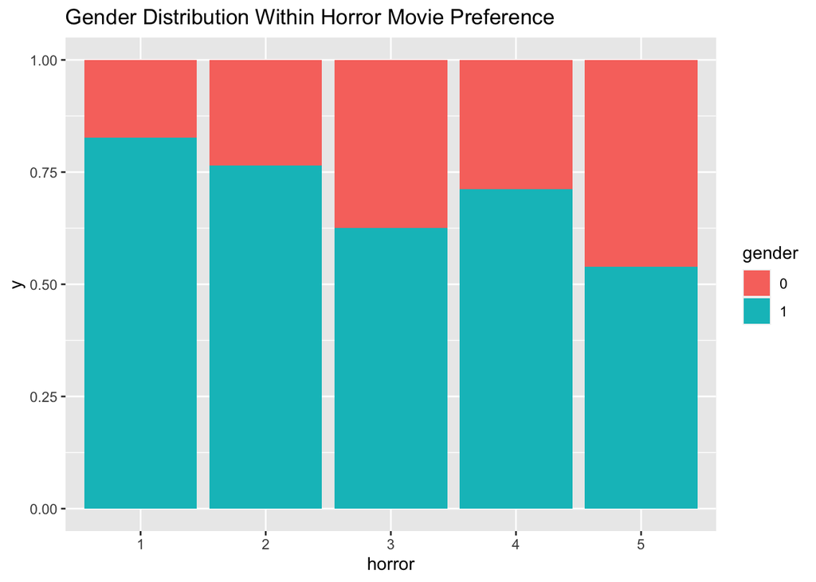

```r
# percent stacked bar chart of survived with fill=gender
ggplot(genre_train, aes(fill=gender, y=1, x=horror)) +
  geom_bar(position="fill", stat="identity") +
  labs(title="Gender Distribution Within Horror Movie Preference")
```

Let’s look at the distribution of `gender`.

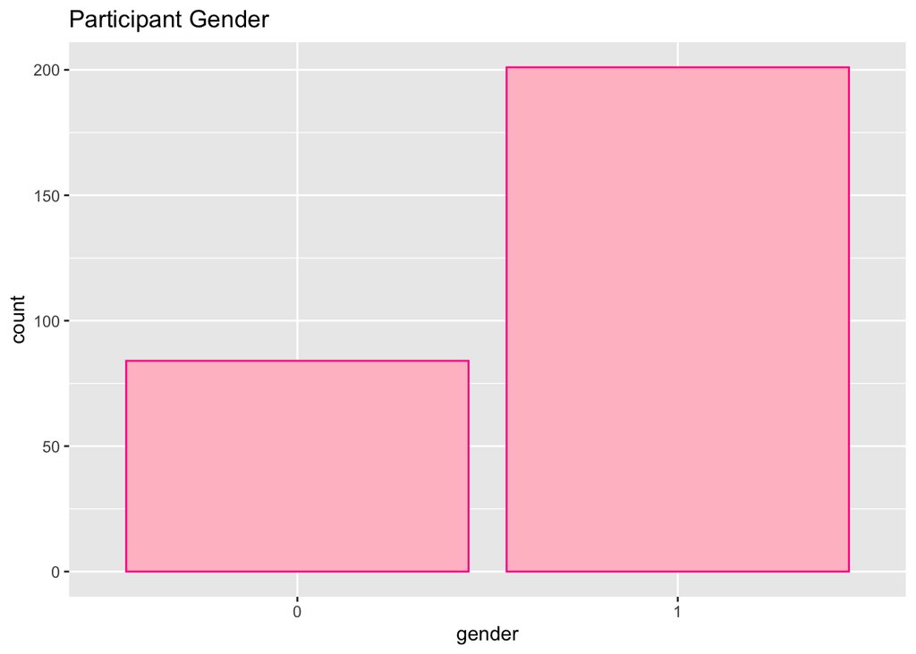

```r
# bar plot of survived to assess the distribution
genre_train %>%
  ggplot(aes(x= gender)) +
  geom_bar(color="deeppink", fill="pink") +
  labs(xlab="Gender", ylab="Count", title="Participant Gender")
```

As indicated by the bar plot, it’s clear there are significantly more women in the study than men. Our results from the percentage stacked bar chart indicate that `gender` distribution does change for each rating of `horror`, so `gender` will probably impact the prediction of `rating`.

Lastly, let’s look at the distribution of `age`.

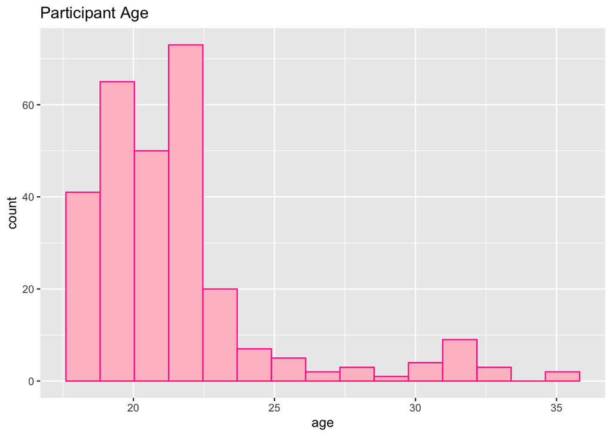

```r
genre_train %>%
  ggplot(aes(x = age)) +
  geom_histogram(color="deeppink", fill="pink", bins = 15) +
  labs(title="Participant Age")
```

# **Fitting Models**

The first thing we need to do before creating our models is to create the cross validation folds. K-fold cross validation is a method to estimate the test error rate when we are fitting a model, which helps us choose which model will best fit our testing data. First, the dataset is randomly divided into k number of folds (for this project we will use k = 10). Each fold is used as a validation set against the remaining combined folds, so that k number of models are fit. Then, the ROC AUC values are calculated for each fold and averaged for model assessment. We will also be stratifying on `horror` so that each fold will have the same proportion of each level of `horror` as in the entire training set.

```r
# creating k folds
genre_folds <- vfold_cv(genre_train, v = 10, strata=horror)
```

Now, it’s time to create our recipe so that we can fit our models. We already subset the data so that includes only the variables we need, so the recipe specification uses all the variables in `genre_training`. Within the recipe, `step_dummy()` dummy codes the nominal variables, which will ensure the model handles them properly. `step_normalize()` scales and centers all the numeric predictors.

```r
# creating recipe
genre_recipe <- recipe(horror ~., data = genre_train) %>%
  step_dummy(all_nominal_predictors()) %>% # dummy tuning
  step_normalize(all_numeric_predictors())  # normalize predictors
prep(genre_recipe) %>%
  bake(new_data = genre_train)
```

```
## # A tibble: 285 × 35
##    ipip_01 ipip_02 ipip_03 ipip_04 ipip_05 ipip_06r ipip_07r ipip_08r ipip_09r
##      <dbl>   <dbl>   <dbl>   <dbl>   <dbl>    <dbl>    <dbl>    <dbl>    <dbl>
##  1  -0.742  -0.176  0.966    1.23   -0.937   -1.22     0.727   -0.249  0.910
##  2   0.295  -0.176  0.966    0.341  -2.01    -1.22    -0.444    0.491  0.910
##  3  -0.742  -0.176  0.966    1.23   -0.937   -2.02     0.727   -0.990  0.910
##  4  -0.742  -0.176  0.966   -0.551  -0.937    0.368   -0.444   -0.249  0.910
##  5   1.33    1.18  -0.0137  -0.551  -2.01    -0.427    0.727    1.23  -0.904
##  6   0.295  -0.176  0.966   -1.44   -0.937    1.16     0.727   -0.249 -0.904
##  7   1.33    1.18   0.966    0.341   0.131   -0.427   -0.444    0.491  0.910
##  8  -1.78   -1.53  -0.993    0.341   0.131   -1.22    -1.61    -0.990  0.910
##  9   1.33    1.18   0.966    1.23    0.131   -0.427    0.727    1.23   0.910
## 10   0.295   1.18   0.966    0.341   0.131   -0.427   -0.444    0.491  0.00318
## # ℹ 275 more rows
## # ℹ 26 more variables: ipip_10r <dbl>, ipip_11 <dbl>, ipip_12 <dbl>,
## #   ipip_13 <dbl>, ipip_14 <dbl>, ipip_15r <dbl>, ipip_16r <dbl>,
## #   ipip_17r <dbl>, ipip_18r <dbl>, ipip_19r <dbl>, ipip_20r <dbl>,
## #   dd_01 <dbl>, dd_02 <dbl>, dd_03 <dbl>, dd_04 <dbl>, dd_05 <dbl>,
## #   dd_06 <dbl>, dd_07 <dbl>, dd_08 <dbl>, dd_09 <dbl>, dd_10 <dbl>,
## #   dd_11 <dbl>, dd_12 <dbl>, age <dbl>, horror <fct>, gender_X1 <dbl>
```

For this data, we will be fitting the data to five models:

- Decision Tree
- Random Forest
- K-Nearest Neighbors
- Elastic Net
- Neural Network

To fit each model, the necessary steps are:

1. Specify model engine, mode, and hyperparameters to be tuned
2. Add the model and recipe to the workflow
3. Create a grid of tuning values
4. Tune hyperparameters using folds
5. Evaluate best hyperparameter values using ROC AUC
6. Finalize workflow with chosen hyperparameters and fit model to training data
7. Fit best models to testing data and evaluate model performance

Let’s start working on our models!

## *Decision Tree*

A decision tree is when an observation goes through a series of questions (nodes) regarding it’s characteristics, with the answer of each question leading to a different branch of the node.

For this model, we will tune:

- `cost_complexity`: cost complexity parameter for pruning the decision tree
  - We will be tuning this value from -3 to -1, in the log-10 scale

```r
# setting engine and mode
genre_tree <- decision_tree(cost_complexity = tune()) %>%
  set_engine("rpart") %>%
  set_mode("classification")

# decision tree workflow
genre_tree_wf <- workflow() %>%
  add_model(genre_tree) %>%
  add_recipe(genre_recipe)

# creating grid for hyperparameter tuning
tree_grid <- grid_regular(cost_complexity(range = c(-3, -1)), levels = 10)
```

This is the code to tune our model, but to save time, I will load in the results from this code.

```r
# tuning hyperparameters
tune_genre_tree <- tune_grid(
  genre_tree_wf,
  resamples = genre_folds,
  grid = tree_grid
)
```

```r
# reading in results
tune_tree_genre <- read_rds(file = "rds_files/tune-tree-results.rds")
```

Let’s see how our first model performed!

```r
# best hyperparameters with this model
show_best(tune_tree_genre, n=1, metric = 'roc_auc')
```

```
## # A tibble: 1 × 7
##   cost_complexity .metric .estimator  mean     n std_err .config
##             <dbl> <chr>   <chr>      <dbl> <int>   <dbl> <chr>
## 1         0.00774 roc_auc hand_till  0.566    10  0.0212 Preprocessor1_Model05
```

The best hyperparameter for this model is `cost_complexity = 0.008`, with a mean ROC AUC of 0.566. So far, this is not great, since we want our AUC to be closer to 1. Let’s work on our next model!

## *Random Forest*

The random forest model functions by putting observations through a number of decision trees, hence the name “random forest”. Each tree produces a predicted outcome based on its individual structure, and the outcome that is predicted the most frequently in the forest is the final output.

For this model, we will be tuning:

- `mtry`: the number of variables to be randomly selected at each split of the node
  - we will be tuning this variables from 1 to 34, since we have a total of 34 predictor variables
- `trees`: the number of decision trees in the random forest
  - we will be tuning this variable from 200 to 500 trees
- `min_n`: the minimum number of observations in a node for the node to be split into further branches
  - we will be tuning this variable from 10 to 20

```r
# setting engine and mode
rf_genre <- rand_forest(mtry = tune(),
                           trees = tune(),
                           min_n = tune()) %>%
  set_engine("ranger") %>%
  set_mode("classification")

# random forest workflow
rf_genre_wf <- workflow() %>%
  add_model(rf_genre) %>%
  add_recipe(genre_recipe)

# creating grid for hyperparameter tuning
rf_grid <- grid_regular(mtry(range = c(1, 34)),
                        trees(range = c(200, 500)),
                        min_n(range = c(10, 20)),
                        levels = 10)
```

```r
# tuning hyperparameters
tune_genre_rf <- tune_grid(
  rf_genre_wf,
  resamples = genre_folds,
  grid = rf_grid
)
```

Let’s look at the hyperparameters that performed the best.

```r
# loading in results
tune_rf_genre <- read_rds(file = "rds_files/tune-rf-results.rds")
# model with best hyperparameters
show_best(tune_rf_genre, n=1, metric = 'roc_auc')
```

```
## # A tibble: 1 × 9
##    mtry trees min_n .metric .estimator  mean     n std_err .config
##   <int> <int> <int> <chr>   <chr>      <dbl> <int>   <dbl> <chr>
## 1     1   266    12 roc_auc hand_till  0.586    10  0.0182 Preprocessor1_Model0…
```

As we can see, the the best hyperparameters for this model include: `trees = 266`, `mtry = 1`, and `min_n = 12`. The mean ROC AUC is 0.586, which is higher than the previous model, but still not very close to 1. Let’s work on our other models to see if they can produce an even better ROC AUC.

## *K-Nearest Neighbors*

The K-Nearest Neighbors model looks at similar observations to sort a data point to a certain outcome. The number of neighbors influences how the data point is sorted, since it assumes observations with similar characteristics will have the same outcome as each other.

We will be tuning:

- `neighbors`: number of neighbors, or similar data points, used to predict an outcome for the observation for the data point
  - We will be tuning this variable from 1 to 10 neighbors

```r
# setting engine and mode
knn_genre <- nearest_neighbor(neighbors = tune()) %>%
  set_mode("classification") %>%
  set_engine("kknn")

# KNN workflow
knn_genre_wf <- workflow() %>%
  add_model(knn_genre) %>%
  add_recipe(genre_recipe)

# creating grid for hyperparameter tuning
knn_grid <- grid_regular(neighbors(range = c(1, 10)), levels = 10)
```

```r
# tuning hyperparameters
tune_genre_knn <- tune_grid(
  object = knn_genre_wf,
  resamples = genre_folds,
  grid = knn_grid
)
```

```r
# reading in tuning results
tune_knn_genre <- read_rds(file = "rds_files/tune-knn-results.rds")
# model with best hyperparameters
show_best(tune_knn_genre, n=1, metric = 'roc_auc')
```

```
## # A tibble: 1 × 7
##   neighbors .metric .estimator  mean     n std_err .config
##       <int> <chr>   <chr>      <dbl> <int>   <dbl> <chr>
## 1         3 roc_auc hand_till  0.555    10  0.0205 Preprocessor1_Model03
```

The best hyperparameter is `neighbors = 3`, which resulted in a mean ROC AUC of 0.555 among the folds. This is the worst AUC thus far, but is still very close to the others.

## *Elastic Net Regression*

This model aims to shrink the coefficients of the predictors and selects the most important variables in the model to predict the response.

We will be tuning:

- `mixture`: the proportion of lasso regularization
  - We will be tuning this variable from 0 to 1
- `penalty`: the amount of total regularization
  - We will be tuning this variable from 0 to 1

```r
# setting engine and mode
en_mod <- multinom_reg(mixture = tune(), penalty = tune()) %>%
  set_mode("classification") %>%
  set_engine("glmnet")

# creating elastic net workflow
en_genre_wf <- workflow() %>%
  add_model(en_mod) %>%
  add_recipe(genre_recipe)

# tuning hyperparameters
en_grid <- grid_regular(penalty(range = c(0, 1), trans = identity_trans()),
                        mixture(range = c(0, 1)), levels = 10)
```

```r
# tuning hyperparameters
tune_genre_en <- tune_grid(
  object = en_genre_wf,
  resamples = genre_folds,
  grid = en_grid
)
```

```r
# reading in results
tune_en_genre <- read_rds(file = "rds_files/tune-en-results.rds")
# model with best hyperparameters
show_best(tune_en_genre, n=1, metric = 'roc_auc')
```

```
## # A tibble: 1 × 8
##   penalty mixture .metric .estimator  mean     n std_err .config
##     <dbl>   <dbl> <chr>   <chr>      <dbl> <int>   <dbl> <chr>
## 1   0.333   0.111 roc_auc hand_till  0.567    10  0.0165 Preprocessor1_Model014
```

The best hyperparameters are `penalty = 0.333` and `mixture = 0.111`, resulting in a mean ROC AUC of 0.567. This is very consistent with the others, so hopefully our final model can get a little higher.

## *Neural Network*

A neural network includes layers of “neurons” that take in observations as input and pass them on to the next neuron after analyzing their information. The model includes input, hidden, and output layers. The observation goes into the input layer, is passed through the numerous hidden layers, and then the prediction is outputted by the output layer.

```r
# setting engine and mode
nn_genre <- mlp(hidden_units = tune(), penalty = tune(), epochs = tune()) %>%
  set_mode("classification") %>%
  set_engine("nnet")

# creating neural network workflow
nn_genre_wf <- workflow() %>%
  add_model(nn_genre) %>%
  add_recipe(genre_recipe)

# tuning hyperparameters
nn_grid <- grid_regular(hidden_units(range(3,7)), penalty(range(0,0.01)), epochs(range(20,25)), levels = 10)
```

```r
# tuning hyperparameters
tune_genre_nn <- tune_grid(
  object = nn_genre_wf,
  resamples = genre_folds,
  grid = nn_grid
)
```

```r
# reading in results
tune_nn_genre <- read_rds(file = "rds_files/tune-nn-results.rds")
# model with best hyperparameters
show_best(tune_nn_genre, n=1, metric = 'roc_auc')
```

```
## # A tibble: 1 × 9
##   hidden_units penalty epochs .metric .estimator  mean     n std_err .config
##          <int>   <dbl>  <int> <chr>   <chr>      <dbl> <int>   <dbl> <chr>
## 1            3    1.02     23 roc_auc hand_till  0.571    10  0.0184 Preprocess…
```

The the best hyperparameters for the neural network model include `hidden_units = 3`, `penalty = 1.018`, and `epochs = 23`. The mean ROC AUC is 0.571, which is the second best performing model based on ROC AUC.

After tuning all of our models, the random forest perfomed the best. However, since all mean AUC values are very close, I would like to fit our second best model, the neural network, to the testing dataset. We will save the best performing hyperparameters to finalize each workflow.

```r
# best hyperparameter and model combinations
best_rf <- select_best(tune_rf_genre, metric = 'roc_auc')
best_nn <- select_best(tune_nn_genre, metric = 'roc_auc')
```

After finalizing the workflows, we will fit them to the training data, and then assess the performance of our model using the testing dataset.

# **Model Results**

## *Random Forest Results*

Let’s use our best hyperparameters to finalize the model.

```r
# finalizing random forest model
final_rf_model <- finalize_workflow(rf_genre_wf, best_rf)
# fitting to training data
final_rf_model <- fit(final_rf_model, genre_train)
```

Next, we’ll use `augment()` to see how well the model can generate predictions on data it has never seen before. Then, we will also calculate the testing ROC AUC for comparison to the mean testing ROC AUC.

```r
# generating predictions
final_rf_model_test <- augment(final_rf_model, genre_test) %>%
  select(horror, starts_with(".pred"))
# testing data ROC AUC
roc_auc(final_rf_model_test, truth = horror, .pred_1:.pred_5)
```

```
## # A tibble: 1 × 3
##   .metric .estimator .estimate
##   <chr>   <chr>          <dbl>
## 1 roc_auc hand_till      0.577
```

The testing ROC AUC value is about 0.01 less than the training mean ROC AUC from this model. While this means the model is not performing very well, it is at least not overfit to the training data, since they are about the same values.

Let’s generate a confusion matrix to visualize the models predictions versus actual values.

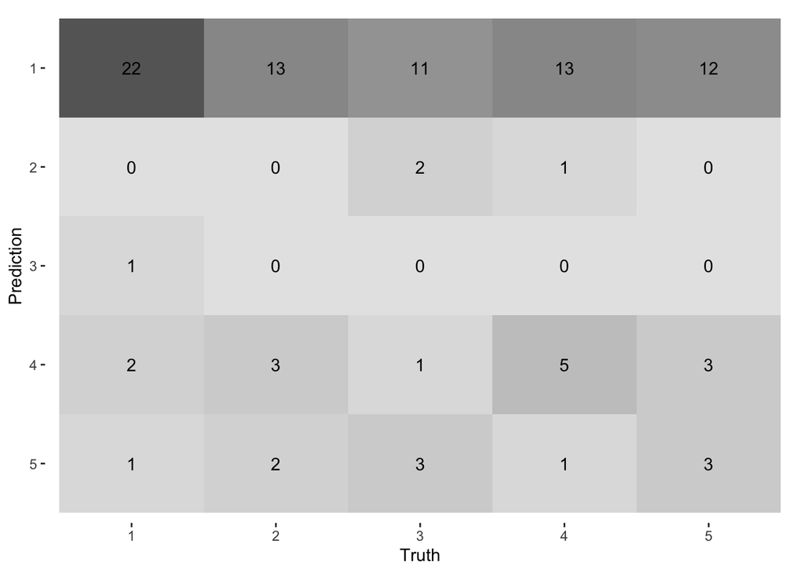

```r
# confusion matrix
conf_mat(final_rf_model_test, truth = horror,
         .pred_class) %>%
  autoplot(type = "heatmap")
```

It seems that the model predicted that most participants would rank `horror` movies with a 1. It did not successfully predict any ratings of 2 or 3, and only successfully predicted a couple of 4 and 5 rankings. From this, it’s clear the model is not very accurate, and will guess a rating of 1 most of the time. From this result, we can interpret that the participant’s personality test results cannot be used to accurately predict their preference for horror movies very accurately.

However, Let’s look at our second best model to see if we can do any better.

## *Neural Network*

We first finalize the model.

```r
# finalizing neural network model
final_nn_model <- finalize_workflow(nn_genre_wf, best_nn)
final_nn_model <- fit(final_nn_model, genre_train)
```

Next, let’s look at the testing ROC AUC.

```r
# testing data ROC AUC
final_nn_model_test <- augment(final_nn_model, genre_test) %>%
  select(horror, starts_with(".pred"))

roc_auc(final_nn_model_test, truth = horror, .pred_1:.pred_5)
```

```
## # A tibble: 1 × 3
##   .metric .estimator .estimate
##   <chr>   <chr>          <dbl>
## 1 roc_auc hand_till      0.549
```

The visualization for the confusion matrix is shown below.

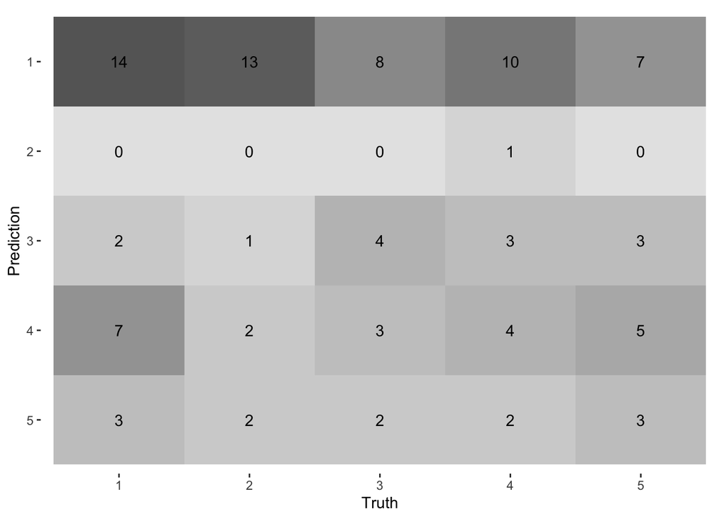

```r
# confusion matrix
conf_mat(final_nn_model_test, truth = horror,
         .pred_class) %>%
  autoplot(type = "heatmap")
```

# **Conclusion**

However, these ROC AUC values demonstrate that none of our models performed exceedingly well. Ideally, we want our ROC AUC to be as close to 1 as possible. An AUC value of 0.5 indicates it cannot differentiate between any of the levels more than a random chance. Thus, because our AUC results are close to 0.5, our model seemingly cannot differentiate between the levels of `horror` very well. For both of the final models, we saw that the model guessed a rating of 1 most of the time. Part of the reason why this may have happened is because 1 was the most popular rating out of the values of `horror`. However, when I initially explored the data, I did not find the difference to be significant. This oversight probably affected how often the model predicted the 1 rating. Another reason for this outcome is likely that personality type simply does not predict a person’s preference in horror movies very well. With these factors combined, our results seem reasonable.

If I were to work on this project further, I would be interested in comparing the models’ predictive abilities of horror books to our results for horror movies. Additionally, I would consider using the responses to the personality questions to score a participant’s specific personality traits, creating 8 new variables. I would then use the 8 personality trait scores in addition to `gender` and `age` to predict the response. This would lead to a wider range of values for the personality trait score, which might be easier for the model to predict a movie or book preference.

Despite my models not performing as well as I would have hoped, I still learned so much from this project. I’m glad to have pushed myself to try a neural network, and I gained valuable experience with different packages and functions in R. Additionally, I think it’s beneficial to see an instance where my models don’t perform very well, since real data is not perfect.

# **Sources**

IPIP information: Donnellan, M. B., Oswald, F. L., Baird, B. M., & Lucas, R. E. (2006). The mini-IPIP scales: Tiny-yet-effective measures of the big five factors of personality. Psychological Assessment, 18(2), 192-203. doi:https://doi.org/10.1037/1040-3590.18.2.192

Dirty Dozen information: Jonason, P. K., & Webster, G. D. (2010). The dirty dozen: A concise measure of the dark triad. Psychological Assessment, 22(2), 420-432. doi:https://doi.org/10.1037/a0019265

Study Accompaning Data: Manolika, M. (2023). The big five and beyond: Which personality traits do predict movie and reading preferences? Psychology of Popular Media., 12(2), 197-206. doi:https://doi.org/10.1037/ppm0000394

[Harvard Dataverse Data Source](https://dataverse.harvard.edu/dataset.xhtml?persistentId=doi:10.7910/DVN/23NDKX)